# hw02

Philip Belov

October 19, 2015

### A path to hypothesis

I have a question: how tickets are distributed amongst agents by language? Is there any correlation between tickets amount, language and agent who’s solving a problem?

Let’s try to build a graph that’ll help me bate my curiosity.

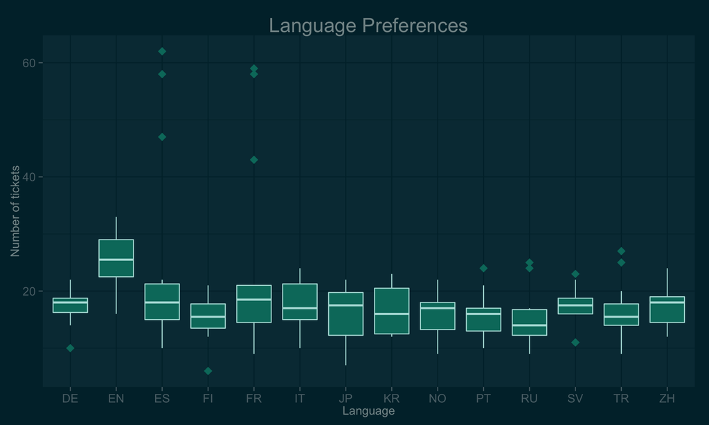

From the boxplot above we can easily notice that there are some outliers which brings us to the idea that perhaps some agents prefer to take tickets in a specific language. So, my **hypothesis** is that **there are agents that prefer a specific language** of the problem they solve.

### Hypothesis testing

Let’s take a Pearson’s Chi-squared test to see if there’s any correlation between the language of a ticket and an agent who solves that ticket.

```
    Pearson's Chi-squared test

data:  tbl_languages
X-squared = 354.06, df = 169, p-value = 3.504e-15
```

> *You can select how Pearson’s residuals values are represented:*

| Agent | DE | EN | ES | FI | FR | IT | JP | KR | NO | PT | RU | SV | TR | ZH |
| --- | --- | --- | --- | --- | --- | --- | --- | --- | --- | --- | --- | --- | --- | --- |
| Adolf | 1.23583767230403 | 1.27168313776558 | -1.60743185889462 | 1.06029209107134 | -2.38360127613276 | -0.190009903530364 | 1.05444200381009 | 1.72418003443646 | 0.119179061749739 | 1.45046446098485 | -1.52979519279275 | 0.29825548794098 | -0.972995387126839 | -0.967209862568673 |
| Adrian | -1.47835748752041 | 2.03731445616488 | -1.56487644644896 | -0.535701746117856 | -1.9436726903188 | -0.192298805507339 | 1.85492294737909 | -0.286077272001442 | 0.89245176119336 | 0.686429457241913 | -0.535701746117856 | 0.311438160658718 | 0.28048945272997 | 0.761252236750829 |
| Albert | -0.438468846730094 | -1.56299270470054 | 3.19334514292825 | -0.351579444529704 | 2.53645751308347 | -0.621617927329315 | 0.0830335560019513 | -0.218484063694582 | -1.43169308740144 | -1.38216144144494 | -0.351579444529704 | -2.15508504874791 | 1.18945592796091 | 0.632286734682144 |
| Gerhard | 1.36099182068468 | 1.30054922273927 | -2.13578216321548 | 0.333062569452338 | -0.378704450131194 | -1.39551161405194 | -0.679637872905787 | 0.038228689596516 | 1.75856639041399 | 0.758100570869784 | 0.0635230194679459 | 0.128840496126335 | -1.47838374823908 | 0.584551166110615 |
| Giselle | -0.558861613730936 | 0.74002109126677 | -1.30041934552387 | -0.836123295523583 | -0.639685378116844 | 0.438021213507749 | 0.201281909275336 | 0.375935389158025 | 0.525026809198112 | -0.93224562173724 | 2.23505215690276 | 0.438021213507749 | -0.560721324744326 | 0.144507166662063 |
| Josephine | -0.22575427245136 | -0.578881294183183 | -2.39476442086672 | 0.800270192498067 | 0.0612305249653061 | 1.8881699693185 | -0.508480793771944 | -0.568909586573978 | 0.0942771219875983 | 0.144733727526343 | 0.247757843807547 | 2.1485595128551 | 0.279352480412848 | -0.758645863735363 |
| Katarina | 0.937301133635436 | 0.00385947081283508 | -1.04590823621628 | 1.5224248950857 | -1.19930915867755 | -0.238123963512553 | 0.750305784138052 | -1.06066473654099 | 1.58446529968359 | 0.3789536564055 | -0.794681035677063 | -0.238123963512553 | -1.26453728301747 | 1.15964169885641 |
| Lulu | -0.396673665635436 | 0.0439408587528658 | -1.18378431039959 | 0.869959523998306 | -2.14007512378451 | 0.352962003993875 | -0.863577968157075 | -1.17075268186055 | 0.442187102416084 | 0.999449644136159 | 0.109612916079604 | 1.0696384968715 | 2.55863887160349 | 0.0617955620568691 |
| Magda | 0.69588014911472 | -1.332924657203 | 0.0986622912419051 | -2.03411742207706 | -0.930065926266286 | 2.2721934971832 | -1.92607553837349 | 1.69787128418155 | -0.00731507169975795 | -0.763283433364922 | 0.963725794885488 | 0.730922421439021 | -0.0899178818489664 | 0.933771941717539 |
| Markus | 0.533295345474371 | 0.472106618765052 | -1.32074373921652 | -0.0449999560547519 | -2.58988474670215 | 1.86627789926337 | 1.34918300633402 | 0.21118445499698 | 1.15727512471569 | -0.95982332333462 | -0.0449999560547519 | 0.567306065969264 | -0.00545033995511815 | -0.516397779494322 |

[output cut: 4 more lines]

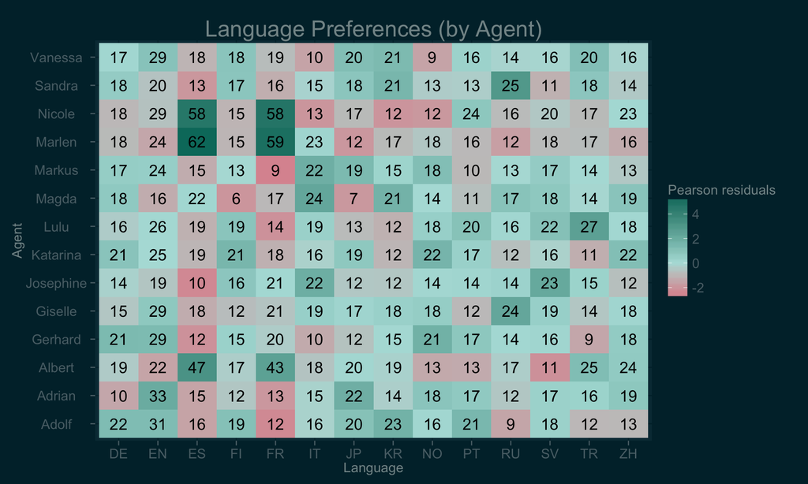

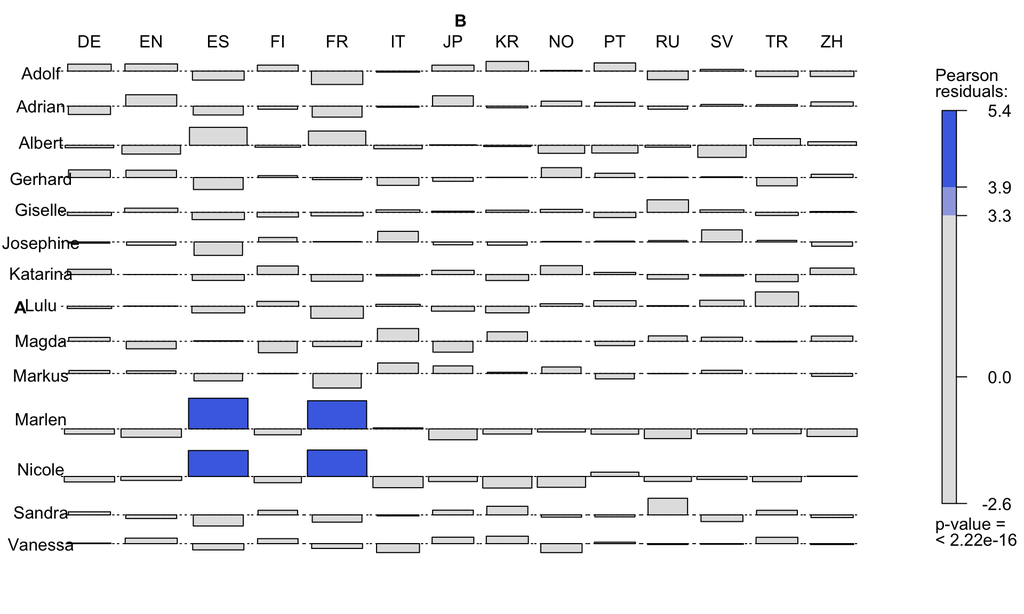

From the *table* above we can conclude that some agents prefer to solve problems reported from a particular country. To be more precise, **Nicole and Marlen prefer to take tickets in either Spanish or French**.